# The Correlation Between Sex and Complaints Against Police Officers

### “The Correlation Between Sex and Complaints Against Police Officers”

Adina Scheinfeld

06/25/2021

The purpose of this project was to analyze the correlation between the sex and complaints against Philadelphia police officers. Analysis was done to compare the association between the sex of the complainant, the sex of the offending officer, and whether complaints by people of one sex were more likely to have their complaints sustained than people of the other sex. A sustained finding occurs when the police department decides that there is enough evidence to support a complaint. Analysis was also done to determine whether there was a correlation between the sex of the offending officer and whether a complaint was sustained.

All data used in this project was taken from OpenDataPhilly which contains data on complaints against police from the past five years (1/19/2016 - 3/31/21).

```r
library(tidyverse)
library(lubridate)
library(scales)
theme_set(theme_bw())
```

```r
# read in findings data from OpenDataPhilly
philly_incidents_findings_from_open_data_philly <-
  read_csv('data/philly_incidents_findings_from_open_data_philly.csv')
# View(philly_incidents_findings_from_open_data_philly)

# read in demographics data from OpenDataPhilly
philly_complainant_demographics_from_open_data_philly <-
  read_csv('data/philly_complainant_demographics_from_open_data_philly.csv')
# View(philly_complainant_demographics_from_open_data_philly)
```

```r
# select only needed columns from findings data
philly_incidents_findings_from_open_data_philly <- philly_incidents_findings_from_open_data_philly %>%
  select(complaint_id, po_sex, investigative_findings)
# View(philly_incidents_findings_from_open_data_philly)

# select only needed columns from demographics data
philly_complainant_demographics_from_open_data_philly <-
  philly_complainant_demographics_from_open_data_philly %>%
  select(complaint_id, complainant_sex)
# View(philly_complainant_demographics_from_open_data_philly)

# join philly_incidents_findings_from_open_data_philly and philly_complainant_demographics_from_open_data_philly
philly_findings_and_demographics_from_open_data_philly <-
  inner_join(philly_incidents_findings_from_open_data_philly,
             philly_complainant_demographics_from_open_data_philly,
             by = "complaint_id")
# View(philly_findings_and_demographics_from_open_data_philly)
```

First, we analyzed the percentage of complaints filed by males with a sustained finding versus the percentage of complaints filed by males with no sustained findings as compared with the percentage of complaints filed by females with a sustained finding versus the percentage of complaints filed by females with no sustained findings. In other words, we analyzed the percentage of complaints that were sustained versus not sustained given that the complainant was a male, as compared with the percentage of complaints that were sustained versus not sustained given that the complainant was a female. As evident from the graphs below, these percentages were *nearly exactly the same* between the sexes. Therefore, the sex of the complainant does *not* seem to be correlated with whether or not the findings of a complaint were sustained.

```r
# count how many sustained findings and no sustained findings per sex
philly_findings_and_demographics_from_open_data_philly_by_sex <-
  philly_findings_and_demographics_from_open_data_philly %>%
  filter((investigative_findings == "Sustained Finding" & complainant_sex == "male") |
           (investigative_findings == "Sustained Finding" & complainant_sex == "female") |
           (investigative_findings == "No Sustained Findings" & complainant_sex == "male") |
           (investigative_findings == "No Sustained Findings" & complainant_sex == "female")) %>%
    group_by(complainant_sex, investigative_findings) %>%
  summarize(num_in_this_category = n())
# View(philly_findings_and_demographics_from_open_data_philly_by_sex)
```

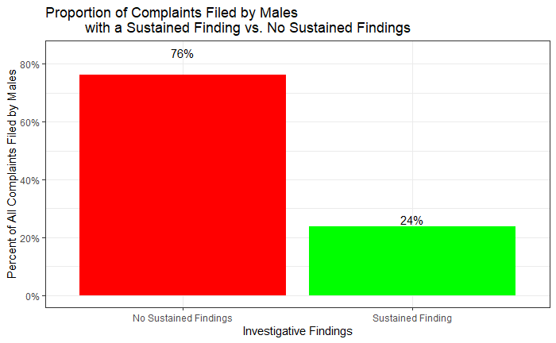

```r
# find the proportion of complaints with sustained finding and no sustained findings
philly_findings_and_demographics_from_open_data_philly_male <-
  philly_findings_and_demographics_from_open_data_philly_by_sex %>%
  filter(complainant_sex == "male") %>%
  mutate(proportion = num_in_this_category / sum(num_in_this_category))
# View(philly_findings_and_demographics_from_open_data_philly_male)

# bar chart
philly_findings_and_demographics_from_open_data_philly_male %>%
  ggplot(aes(x = investigative_findings, y = proportion)) +
  geom_bar(stat = "identity", fill = c("red", "green")) +
  # label each bar with the percentage
  geom_text(aes(label = percent(proportion)), position = position_stack(vjust = 1.1)) +
  # set the y axis labels to be percents
  scale_y_continuous("Percent of All Complaints Filed by Males", labels = percent) +
  # label the x axis
  xlab("Investigative Findings") +
  # title the graph
  ggtitle("Proportion of Complaints Filed by Males
          with a Sustained Finding vs. No Sustained Findings")
```

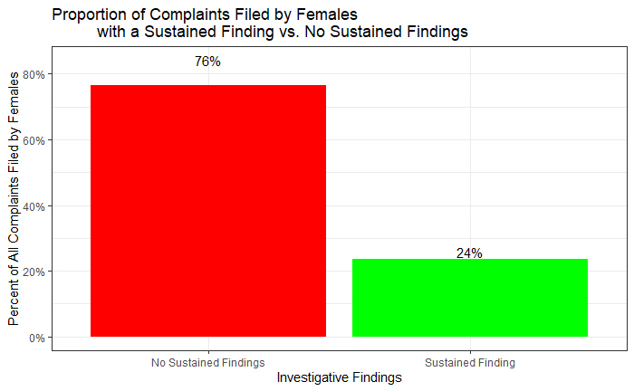

```r
# find the proportion of complaints with sustained finding and no sustained findings
philly_findings_and_demographics_from_open_data_philly_female <-
  philly_findings_and_demographics_from_open_data_philly_by_sex %>%
  filter(complainant_sex == "female") %>%
  mutate(proportion = num_in_this_category / sum(num_in_this_category))
# View(philly_findings_and_demographics_from_open_data_philly_female)

# bar chart
philly_findings_and_demographics_from_open_data_philly_female %>%
  ggplot(aes(x = investigative_findings, y = proportion)) +
  geom_bar(stat = "identity", fill = c("red", "green")) +
  # label each bar with the percentage
  geom_text(aes(label = percent(proportion)), position = position_stack(vjust = 1.1)) +
  # set the y axis labels to be percents
  scale_y_continuous("Percent of All Complaints Filed by Females", labels = percent) +
  # label the x axis
  xlab("Investigative Findings") +
  # title the graph
  ggtitle("Proportion of Complaints Filed by Females
          with a Sustained Finding vs. No Sustained Findings")
```

Next, we analyzed the proportion of complaints filed by people of each gender with a sustained finding versus no sustained finding divided also by the sex of the offending officer. As indicated in the table and the graphs below, these percentages were very similar between the genders. In other words, the sex of the offending officer did not seem to be correlated with whether or not a finding was sustained regardless of whether the complainant was male or female.

| —— | No Sustained Findings | Sustained Finding |
| --- | --- | --- |
| Filed by Male | 75.6% | 24.4% |
| Filed by Male | 73.1% | 26.9% |
| Filed by Female | 76.0% | 24.0% |
| Filed by Female | 73.5% | 26.5% |

Key:  
Filed against Male  
Filed against Female

```r
# count how many sustained findings and no sustained findings per sex
philly_findings_and_demographics_from_open_data_philly_by_complainant_sex_and_po_sex <-
  philly_findings_and_demographics_from_open_data_philly %>%
  group_by(complainant_sex, investigative_findings) %>%
  filter((investigative_findings == "Sustained Finding" & complainant_sex == "male") |
           (investigative_findings == "Sustained Finding" & complainant_sex == "female") |
           (investigative_findings == "No Sustained Findings" & complainant_sex == "male") |
           (investigative_findings == "No Sustained Findings" & complainant_sex == "female")) %>%
  group_by(complainant_sex, po_sex, investigative_findings) %>%
  summarize(num_in_this_category = n()) %>%
  drop_na(po_sex)
# View(philly_findings_and_demographics_from_open_data_philly_by_complainant_sex_and_po_sex)
```

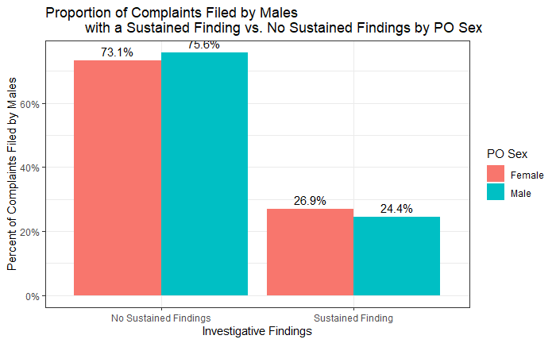

```r
# find proportion of complaints filed by male complainants that were sustained and not sustained by po_sex
male_complainant_and_po_sex <-
  philly_findings_and_demographics_from_open_data_philly_by_complainant_sex_and_po_sex %>%
  # keep only male complainants
  filter(complainant_sex == "male") %>%
  # calculate the proportion
  mutate(proportion = num_in_this_category / sum(num_in_this_category))
# View(male_complainant_and_po_sex)

male_complainant_and_po_sex %>% ggplot(aes(x = investigative_findings, y = proportion, fill = po_sex)) +
  geom_bar(stat = "identity", position = "dodge") +
  # label each bar with the percentage
  geom_text(aes(label = percent(proportion)), position = position_dodge(width = 0.9), vjust = -0.5) +
  # set the y axis labels to be percents
  scale_y_continuous("Percent of Complaints Filed by Males", labels = percent) +
  # label the x axis
  xlab("Investigative Findings") +
  scale_fill_discrete("PO Sex", labels = c("Female", "Male")) +
  # title the graph
  ggtitle("Proportion of Complaints Filed by Males
          with a Sustained Finding vs. No Sustained Findings by PO Sex")
```

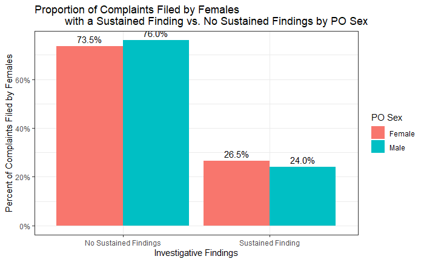

```r
female_complainant_and_po_sex <-
  philly_findings_and_demographics_from_open_data_philly_by_complainant_sex_and_po_sex %>%
  # keep only female complainants
  filter(complainant_sex == "female") %>%
  # calculate the proportion
  mutate(proportion = num_in_this_category / sum(num_in_this_category))
# View(female_complainant_and_po_sex)

female_complainant_and_po_sex %>% ggplot(aes(x = investigative_findings, y = proportion, fill = po_sex)) +
  geom_bar(stat = "identity", position = "dodge") +
  # label each bar with the percentage
  geom_text(aes(label = percent(proportion)), position = position_dodge(width = 0.9), vjust = -0.5) +
  # set the y axis labels to be percents
  scale_y_continuous("Percent of Complaints Filed by Females", labels = percent) +
  # label the x axis
  xlab("Investigative Findings") +
  scale_fill_discrete("PO Sex", labels = c("Female", "Male")) +
  # title the graph
  ggtitle("Proportion of Complaints Filed by Females
          with a Sustained Finding vs. No Sustained Findings by PO Sex")
```

Next, we analyzed the proportion of sustained findings filed by males as compared with the proportion of sustained findings filed by females. In other words, given that a complaint was sustained, what was the probability that the complainant was male versus female. As evident from the chart below, a complaint filed by a male seems to be more likely to be sustained than a complaint filed by a female. However, further analysis is required to determine if this finding is significant or if there is another factor, such as males filing a greater number of complaints than females, that may be the cause for this difference in proportion.

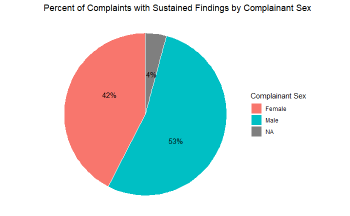

```r
# find the proportion of sustained findings per sex
philly_sustained_findings_per_sex <- philly_findings_and_demographics_from_open_data_philly %>%
  group_by(complainant_sex) %>%
  # keep only complaints with sustained findings
  filter(investigative_findings == "Sustained Finding") %>%
  # count the number of complaints with sustained findings per sex
  summarize(num_complaints = n()) %>%
  # calculate the proportion of sustained findings by each sex
  mutate(proportion_of_sustained_findings = num_complaints / sum(num_complaints))
# View(philly_sustained_findings_per_sex)

# pie chart
philly_sustained_findings_per_sex  %>%
  ggplot(aes(x = "", y = proportion_of_sustained_findings, fill = complainant_sex)) +
  geom_bar(stat = "identity", width = 1, color = "white") +
  coord_polar("y", start = 0) +
  # label each segment in the chart
  geom_text(aes(label = percent(proportion_of_sustained_findings)), position = position_stack(vjust = 0.6)) +
  theme_void() +
  # set the key
  scale_fill_discrete("Complainant Sex",
                      labels = c("Female", "Male")) +
  # title the chart
  ggtitle("Percent of Complaints with Sustained Findings by Complainant Sex")
```

Further analysis into percentage of all complaints which were filed by males as compared with the percentage of all complaints filed by females indicated that males are more likely to file complaints than females, so the discrepancy between the proportion of complaints that are sustained which are filed by males as compared with the proportion of complaints that are sustained which are filed by females may be due to the fact that males file more complaints than females. As evident from the pie chart below, the difference in proportion between the total number of complaints filed by males versus females is nearly identical to the difference in proportion between the number of sustained complaints filed by males versus females.

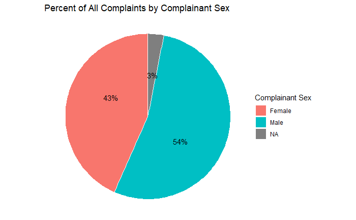

```r
# find the proportion of all complaints per sex
philly_complaints_per_sex <- philly_findings_and_demographics_from_open_data_philly %>%
  group_by(complainant_sex) %>%
  # count the number of all complaints per sex
  summarize(num_complaints = n()) %>%
  # calculate the proportion of all complaints for each sex
  mutate(proportion_of_all_findings = num_complaints / sum(num_complaints))
# View(philly_complaints_per_sex)

# pie chart
philly_complaints_per_sex  %>%
  ggplot(aes(x = "", y = proportion_of_all_findings, fill = complainant_sex)) +
  geom_bar(stat = "identity", width = 1, color = "white") +
  coord_polar("y", start = 0) +
  # label each segment in the chart
  geom_text(aes(label = percent(proportion_of_all_findings)), position = position_stack(vjust = 0.6)) +
  theme_void() +
  # set the key
  scale_fill_discrete("Complainant Sex",
                      labels = c("Female", "Male")) +
  # title the chart
  ggtitle("Percent of All Complaints by Complainant Sex")
```